# A Methodological Review and Practical Agenda for Experimental Social Sciences in Latin America

Valentina González Madariaga  
Coauthors: Tania Hutt · Isidora Jeria

ACES Conference | Paris, France

2026-08-26

## Project context

This bibliometric review maps the regional context in which experimental designs are being developed: **where these studies are produced, what they study, and which methods they use.**

**Wider project**

FONDECYT in Female labor market discrimination in Chile, led by Tania Hutt.

**Design focus**

Motherhood and potential fertility penalties from supply and demand perspectives.

**This phase**

Mapping experimental research in and about Latin America.

**Purpose**

Building regional context for future experimental design.

## Guiding question and analytical steps

Is Latin America becoming a producer of experimental social science, and how are these methods situated in the region?

**1. Evolution**

Trace experimental production in Latin America over time (1990-2026).

**2. Relative presence**

Compare experimental output with total social science production in Latin America and the United States.

**3. Two dimensions**

Distinguish research produced with regional institutional participation from research about the region.

**4. Research profile**

Identify the disciplines, countries, and design families shaping the corpus.

## Search and coding decisions

**Search universe**

Web of Science Core Collection, articles and early access records between **1990-2026**

**Experimental signal**

Title, abstract, and keywords: *survey, field, conjoint, vignette, factorial, audit/correspondence, list, choice, and online experiments.*

**Geographic scope**

Fourteen Latin American countries with enough WoS coverage (>500 records) to support comparison across the period.

**Disciplinary filter**

WoS categories regrouped into six analytical fields: Economics, Political Science, Sociology, Psychology, Business/Management, and Other (e.g. : Women Studies, Demography, Urban Studies)

## Two analytical dimensions

**Endogenous production**

At least one author has a Latin American institutional affiliation.

This identifies regional participation in experimental research production.

**Laboratory research**

The study focuses on Latin America in the title, abstract, or keywords, regardless of author location.

This identifies research about the region as an empirical setting.

The two dimensions **are not mutually exclusive**: a record can be both produced with Latin American institutional participation and focused on Latin America.

## Corpus composition, 1990-2026

**297**

Endogenous only

**421**

Laboratory only

**418**

Both

**1,136**

Total corpus

The total corpus deduplicates records across the endogenous and laboratory searches.

## Search universes, 1990-2026

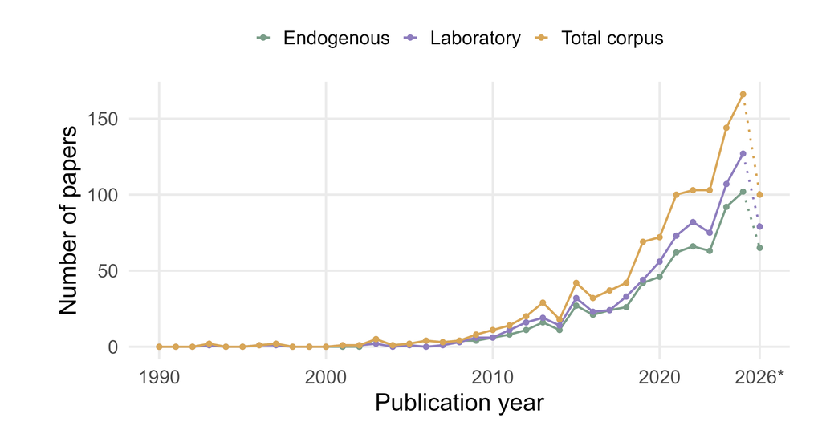

The lines show different search lenses; 2026 is partial.

## Relative output, 1990-2026

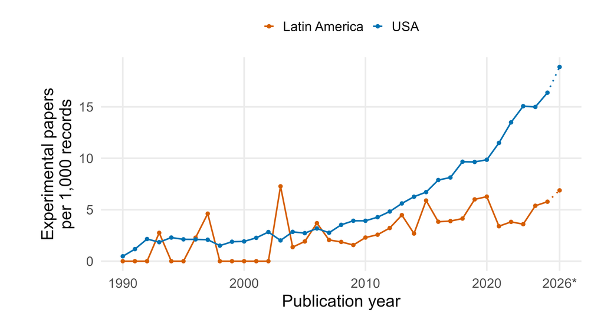

**2025 snapshot**

Latin America**5.8**102 / 17,648

USA**16.4**1,144 / 69,863

Rates are not raw volumes; 2026 is partial.

## Country rates, 1990-2026

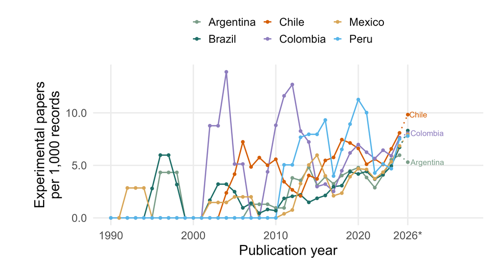

**Endogenous by country**

| Country | Papers |
| --- | --- |
| Brazil | 163 |
| Chile | 160 |
| Colombia | 130 |
| Mexico | 120 |
| Argentina | 65 |
| Peru | 47 |

Rates vary with publication bases; 2026 is partial.

## Core disciplines, 1990-2026

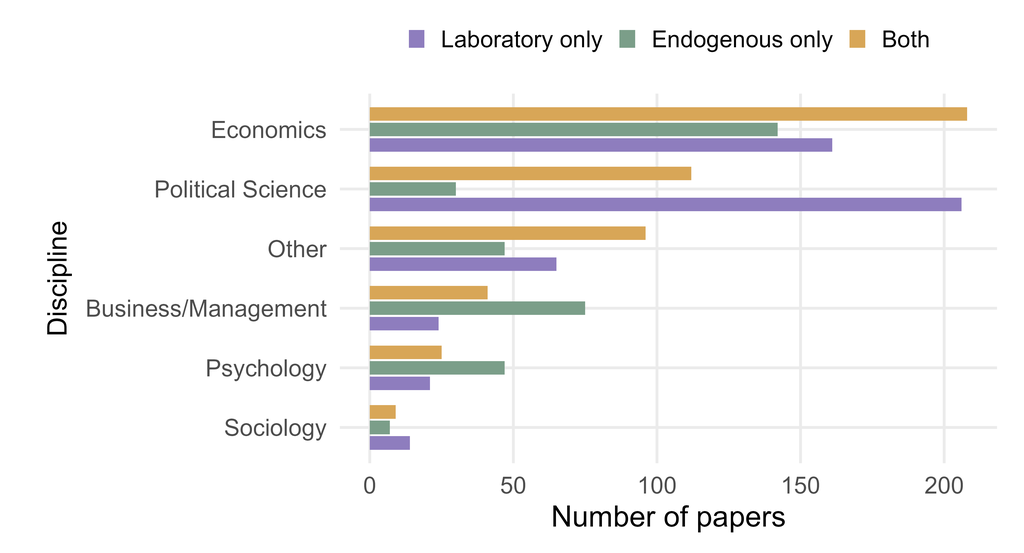

Search-status groups are mutually exclusive; WoS core areas can overlap.

**Experimental sociology:** Sociology represents 30 records in the total corpus, making the methodological discussion especially relevant for this audience.

## Design families, 1990-2026

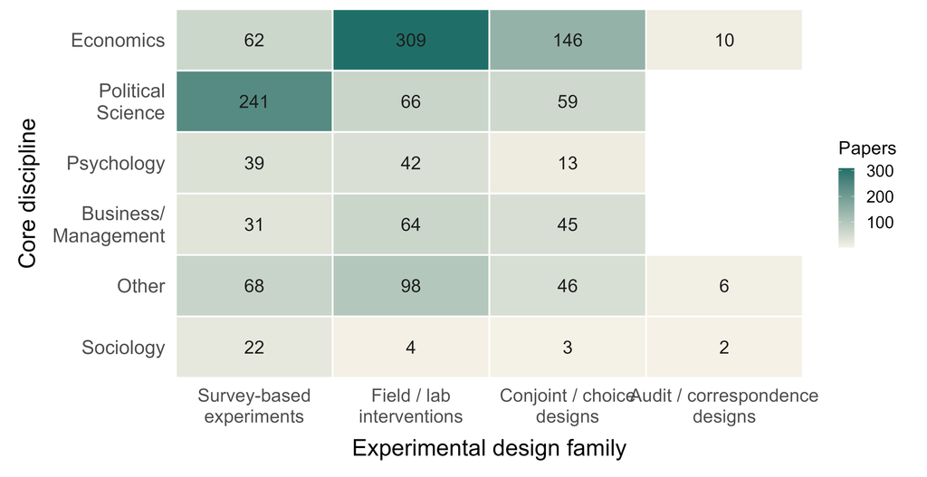

Design families vary across core disciplines.

Families: survey-based = survey, vignette, factorial, list, online; conjoint/choice = conjoint and choice; audit/correspondence = audit, correspondence, resume/CV.

## Main points

**Country patterns**

Country-level rates should be read together with publication volume. They show heterogeneous trajectories, not a single Latin American pattern.

**Disciplinary profile**

The corpus is uneven across core areas. Sociology is present but small, which makes the methodological discussion especially relevant for this audience.

**Design families**

Experimental work is not methodologically uniform. Field/lab interventions, survey-based designs, conjoint/choice designs, and audit/correspondence designs organize different parts of the field.

**Current limits**

The corpus is still being validated. WoS coverage varies, 2026 is partial, affiliation does not equal leadership, and country coding from titles, abstracts, and keywords requires manual checks.

## Next steps

**Takeaways**

- The region should be treated simultaneously as a site of study, a site of production, and a space of collaboration.
- Rates and volumes answer different questions; both are needed to avoid overstating early or partial-year peaks.
- Search metadata gives us the map, but not yet the full social organization of the research field.

**Next steps**

- Complete record-level validation of abstracts, keywords, affiliations, and authorship roles.
- Map citation networks to examine diffusion, dependency, and bridges between endogenous and laboratory research.
- Use topic modeling to identify thematic clusters and connect them to design choices and regional constraints.

## Appendix: Absolute experimental output, 1990-2026

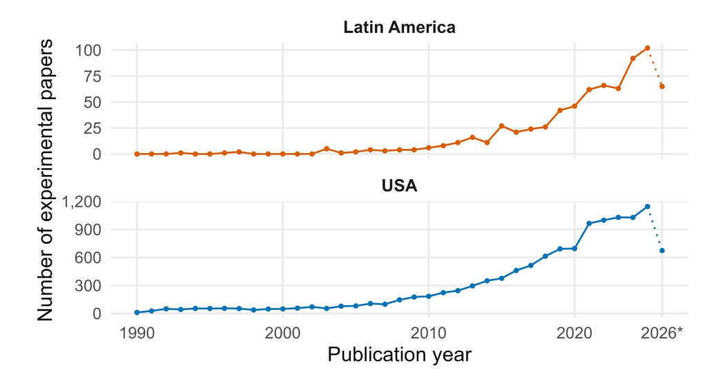

The absolute counts are shown in separate panels because USA volume is much larger. The 2026 point is partial and marked with an asterisk.

## Appendix: Endogenous production by affiliation country

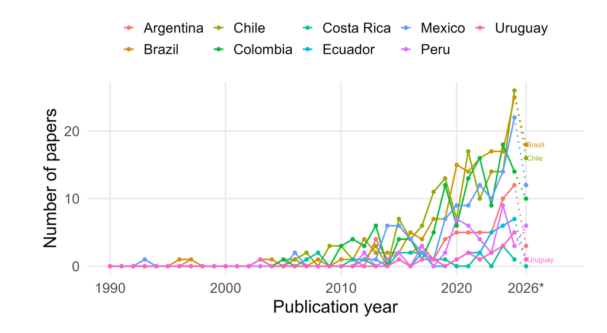

Annual endogenous production is concentrated in a small group of affiliation countries, with different growth trajectories over time. The 2026 point is partial.

## Appendix: Records meeting one or both search criteria

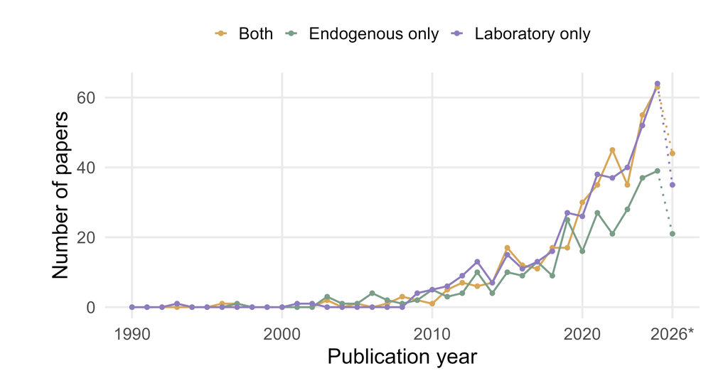

The 2026 point is partial. Before 2026, overlap grows, but endogenous-only and laboratory-only records remain substantial parts of the corpus.

## Thank You

**Valentina González Madariaga**

vsgonzalez2@uc.cl

[Instagram: @costo_de_maternar](https://www.instagram.com/costo_de_maternar/)

[LinkedIn: Costo de Maternar](https://www.linkedin.com/company/costo-de-maternar)

[figure not shown]